# Statistics on fine-mapping results

Andrey Ziyatdinov

2018-08-17

# 1 Table of 22 Loci

[output not shown]

# 2 Fine-mapping results (maximum 1 causal)

Current set-up:

- The 1000 Genome as a LD reference panel
  - Following the protocol from [Paintor](https://github.com/gkichaev/PAINTOR_V3.0/wiki/2a.-Computing-1000-genomes-LD) (all discordant SNPs are simply ignored)
- The FINEMAP program with the maximum number of causals equal to 1
  - Not an optimal configuration. Results in picking SNPs with the top P-values (see figures below).

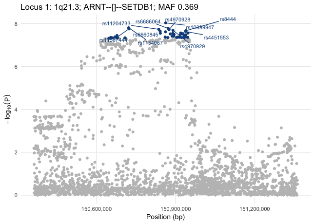

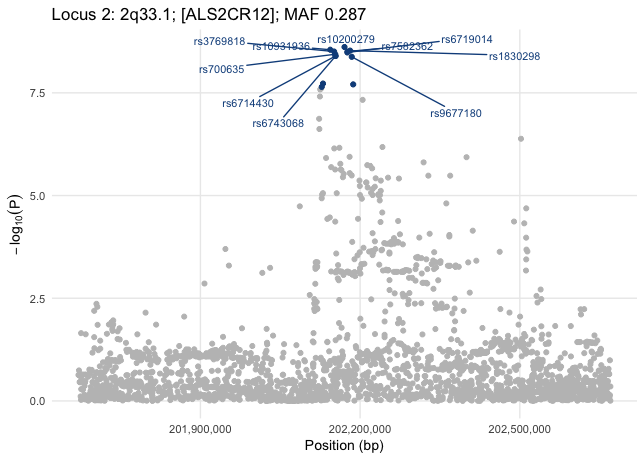

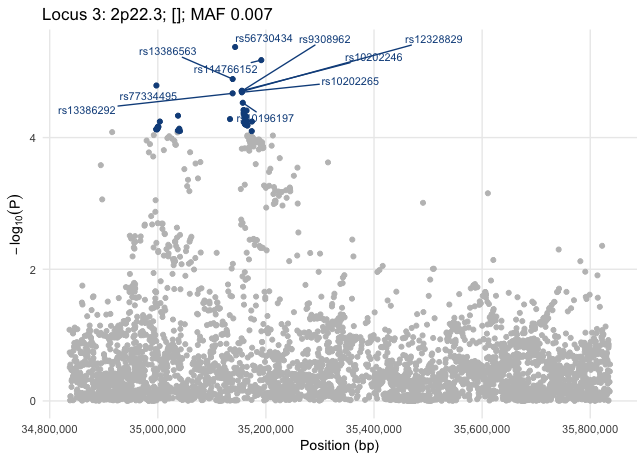

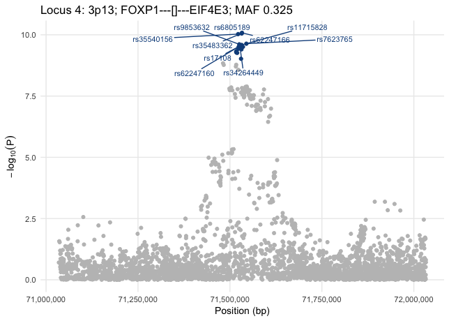

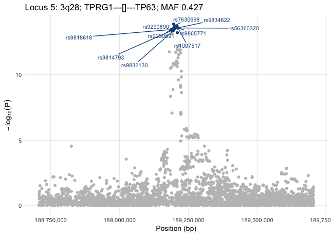

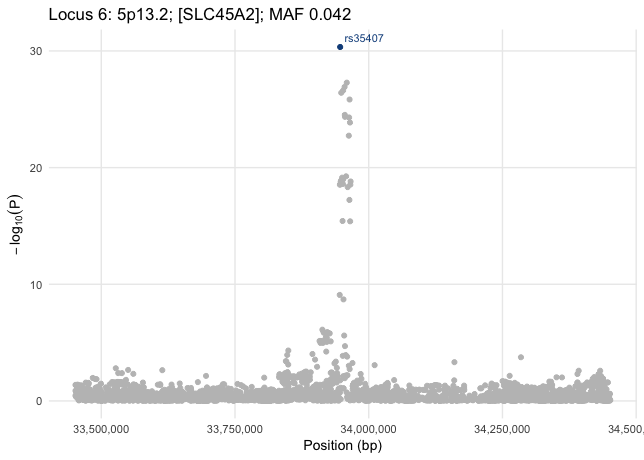

[figure not shown]

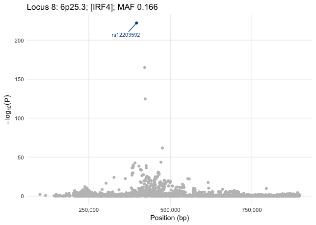

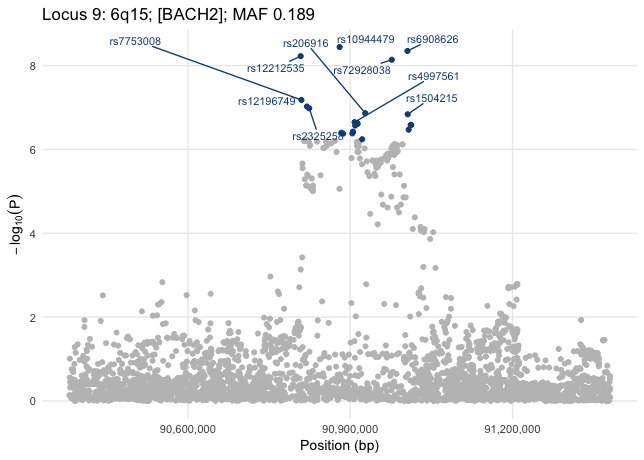

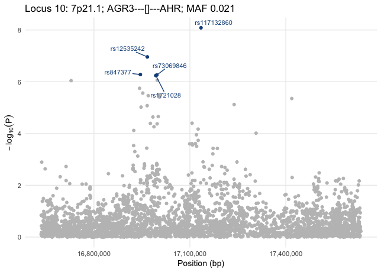

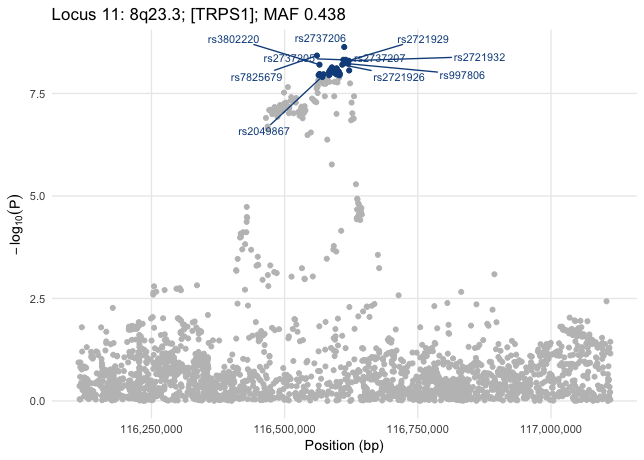

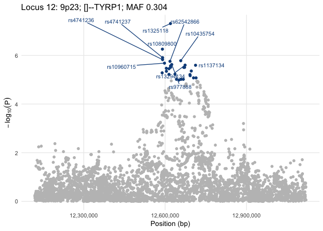

[10 more figures not shown]

## 2.1 Size of the credible set

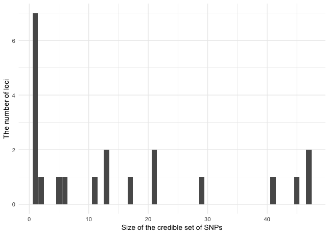

# 3 Overlap with functional categories (53 baseline LD)

LDSC results from our work on GWAS:

| Annotation | SNPs | h2 | Enrich. P | Padj |
| --- | --- | --- | --- | --- |
| Coding_UCSC.extend.500_0 | 0.0646 | 0.432 (0.1286) | 6.691 (1.992) | 0.000848 |
| SuperEnhancer_Hnisz.extend.500_0 | 0.1716 | 0.368 (0.0582) | 2.147 (0.339) | 0.001230 |
| SuperEnhancer_Hnisz_0 | 0.1684 | 0.339 (0.1023) | 2.010 (0.608) | 0.010818 |
| H3K4me1_Trynka.extend.500_0 | 0.6092 | 1.034 (0.1940) | 1.697 (0.318) | 0.005483 |
| Repressed_Hoffman.extend.500_0 | 0.7191 | 0.390 (0.1149) | 0.542 (0.160) | 0.003498 |
| CTCF_Hoffman_0 | 0.0238 | -0.341 (0.1243) | -14.302 (5.217) | 0.008527 |

Statistics among `325` SNPs in credible sets for 22 Loci:

- `n`: the number of SNPs in category;
- `prop`: the proportion.

| annot | n | prop |
| --- | --- | --- |
| H3K4me1_Trynka | 171 | 0.5262 |
| Repressed_Hoffman | 146 | 0.4492 |
| SuperEnhancer_Hnisz | 69 | 0.2123 |
| Coding_UCSC | 16 | 0.0492 |
| CTCF_Hoffman | 5 | 0.0154 |

It is hard to say if there is any enrichment without a formal test (to be done in the future).

# 4 On-going results

## 4.1 LD reference panel from the Harvard cohort

A brief summary of LD info. from Connie (Loci 1 and 2):

```
Summary for region 1 and 2:

Region 1:
Number of total SNPs in both GWAS and OncoArray with Rsq>0.3: 7403
Number of AT and CG alleles SNPs: 1114 (573 flipped, 541 not flipped)
Number of other alleles SNPs: 6289 (2465 flipped, 3824 not flipped)
Number of tri-allelic SNPs: 44 (see diff_alleles_in_gwas_and_onco_r1.txt)

Region 2:
Number of total SNPs in both GWAS and OncoArray with Rsq>0.3: 8586
Number of AT and CG alleles SNPs: 1217 (620 flipped, 597 not flipped)
Number of other alleles SNPs: 7369 (3084 flipped, 4285 not flipped)
Number of tri-allelic SNPs: 76 (see diff_alleles_in_gwas_and_onco_r2.txt)
```

# 5 On-going challenges

## 5.1 The maximum number of causals

### 5.1.1 Greedy for the number of causals

The FINEMAP algorithm always suggests the maximum number of causals.

Fine-mapping output for Locus 1 when a configuration on the number of causals ranges from 1 to 10:

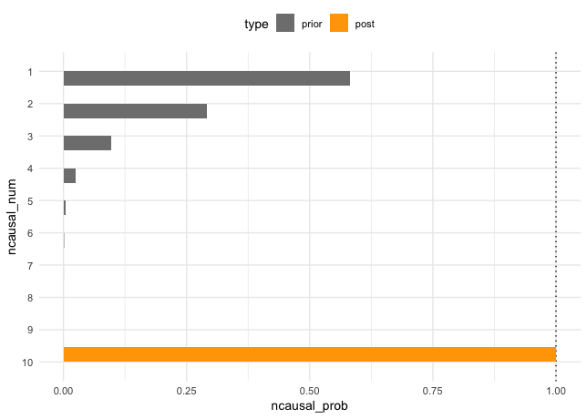

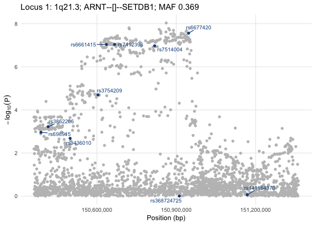

### 5.1.2 Inconsistent results when varying the maximum number of causals

Fine-mapping output for Locus 1 for different values of the maximum number of causals:

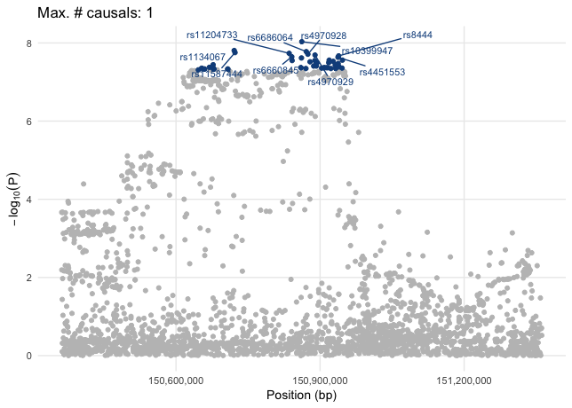

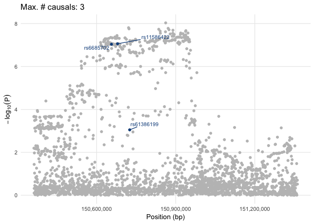

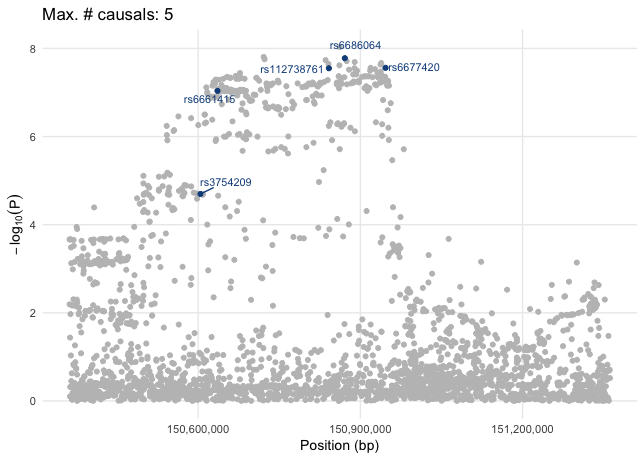

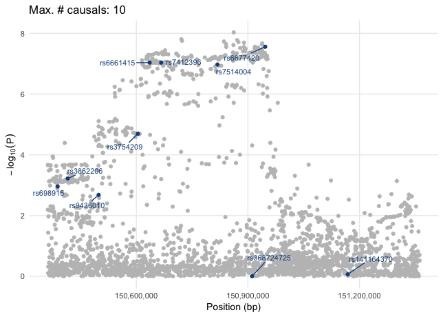

## 5.2 Missing SNPs in LD reference panel

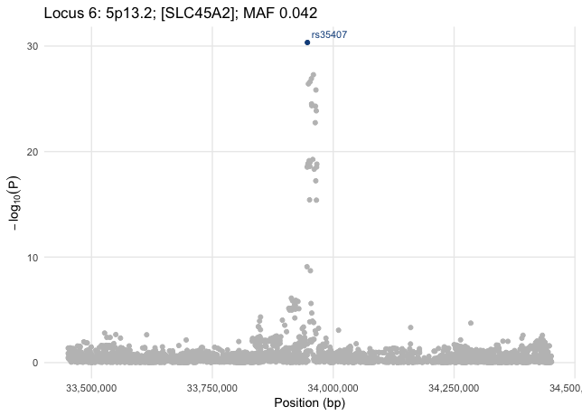

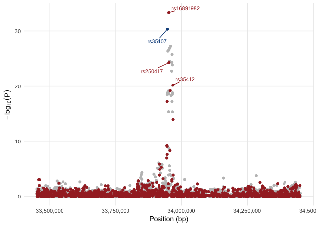

The total ammount of missing LD information: `3439 fine-mapped + 1545 missing Z/LD = 4984 in total`

```
 - tables of results: `config`, `snp`, `ncausal`
 - locus: 1
  -- config:
  -- input snps: 3439 fine-mapped + 1545 missing Z/LD = 4984 in total
# A tibble: 50 x 4
   rank config  config_prob config_log10bf
  <int> <chr>         <dbl>          <dbl>
1     1 rs35407    0.998              27.5
2     2 rs28777    0.000928           24.5
3     3 rs35389    0.000403           24.1
# ... with 47 more rows
  -- snp:
# A tibble: 4,984 x 6
  snp     rank_z rank_pp snp_prob snp_prob_cumsum snp_log10bf
  <chr>    <int>   <int>    <dbl>           <dbl>       <dbl>
1 rs35407      2       1 0.998              0.998       6.31
2 rs28777      3       2 0.000900           0.999       0.504
3 rs35389      4       3 0.000400           1.000       0.141
# ... with 4,981 more rows
  -- 1 snps in 95% credible set: rs35407...
```